# Code Through - rtweet

Elyse King

October 03, 2020

## Introduction to rtweet Package

Twitter has been a powerful platform used from politics to inspiring social movements to building online communities of like-minded individuals. For this class’s code through, I’ll be going over how to collect tweets from Twitter and how to analyze data from that collection.

[figure not shown]

## Current Use Case

One of the most fun use cases I have come across in R programming is figuring out all the ways we can use public data to gather insights about various topics. For example, the article from the NY Times that used R to analyze the twitter accounts to figure out who wrote an op-ed was a powerful example on what can be done with Twitter. For today’s code through, I’ll be going over a less exciting example, but nonetheless with help you gain a grasp on what you can accomplish with this awesome package, rtweet. Through out this process I will go over my own Twitter account and analyze what are the most common themes I discuss in my tweets.

# Step 1:Load your Libraries and Authenticate

For this project, we will be using tidyverse’s ggplot, dplyr, and rtweet. Create a code block to load your these libraries.

Next, we need to authenticate using Twitter’s API.*

*Now, it is said in rcran that you do not need to have Twitter API access using a Twitter Developer Account. However, I found that for ease of use and ensuring that authentication is streamlined, I recommend a developer account.You will need to apply for a developer account and then provide reasoning as to why you need access.

Apply for a Twitter Dev account here: https://developer.twitter.com/en/apply-for-access

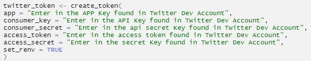

# Basic Functions:

*Searching for Tweets*

*Description on rCran* Returns Twitter statuses matching a user provided search query. ONLY RETURNS DATA FROM THE PAST 6-9 DAYS. To return more than 18,000 statuses in a single call, set “retryonratelimit” to TRUE.search_tweets2 Passes all arguments to search_tweets. Returns data from one OR MORE search queries.

*Example* Let’s look at an example of how to search tweets and assign to an object. I’m going to search for tweets related to a hashtag I follow which is #DataTribe. It’s a small group of Salesforce Data Analytics users.

Below here, “q” represents what you want to be searching, “type” is asking what data you want to return. Twitter’s REST API documentation has a list of what is available: https://developer.twitter.com/en/docs/twitter-api/api-reference-index. “n” is the number of results you want to share, and “include_rts” is a TRUE or FALSE option asking if you want to include retweets or not.

The table of data below will show you the return results.

```r
einstein <- search_tweets(q = "datatribe", in_reply_to_status_id = NULL, retweet_count = 0, type = "recent", n=5, include_rts=FALSE)


tibble(einstein$screen_name, einstein$text)
```

```
## # A tibble: 5 x 2
##   `einstein$screen_na~ `einstein$text`
##   <chr>                <chr>
## 1 coachmaux            "What would you do with $2 million? @DataTribe #CyberSec~
## 2 coachmaux            "What would you do with $2 million? @DataTribe #challeng~
## 3 TonySurak            "Four more weeks to submit for the 3rd Annual DataTribe ~
## 4 DataDreamin          "We got some Friday data fun for y'all \U0001f4ca\n\nThe~
## 5 NassGian             "#Datatribe I need you to read this.\n\nThere are no suc~
```

*Showing Tweets From a Specific User Account*

*Description on rCran* Returns up to 3,200 statuses posted to the timelines of each of one or more specified Twitter users.

*Example* For this example, I want to bring up my tweets so that we can use this data in later examples. In the following example, I also remove retweets and replies so we get what I solely tweet about.

```r
#Get tweets from my timeline, limit to recent tweets, capped at 1000, exclude retweets and replies.

elysecara1 <- get_timeline("@elysecara1", n= 1000, exclude_retweets = TRUE, exclude_replies = TRUE ,type= "recent")

tibble(elysecara1$screen_name, elysecara1$text)
```

```
## # A tibble: 484 x 2
##    `elysecara1$screen_na~ `elysecara1$text`
##    <chr>                  <chr>
##  1 ElyseCara1             "First #peloton ride https://t.co/3WhpRpEyFt"
##  2 ElyseCara1             "I’m giving up on sleeping tonight. I haven’t slept t~
##  3 ElyseCara1             "How do you stop ruminating on what you could’ve answ~
##  4 ElyseCara1             "Overall I think the interview went well but I forgot~
##  5 ElyseCara1             "Today in my interview I was asked “how do you keep u~
##  6 ElyseCara1             "Hey guys, I have a \"created by\" field on the task ~
##  7 ElyseCara1             "#NewProfilePic https://t.co/NRPZyZTkCN"
##  8 ElyseCara1             "If a democracy falls in a forest does it make a soun~
##  9 ElyseCara1             "Find your inner athlete."
## 10 ElyseCara1             "I have a potential opportunity coming up with a high~
## # ... with 474 more rows
```

# Analyzing Tweets:

*Most Frequented Words*

[figure not shown]

```r
elysecara1$text <-  gsub("https\\S*", "", elysecara1$text)
elysecara1$text <-  gsub("@\\S*", "", elysecara1$text)
elysecara1$text  <-  gsub("amp", "", elysecara1$text)
elysecara1$text <-  gsub("[\r\n]", "", elysecara1$text)
elysecara1$text <-  gsub("[[:punct:]]", "", elysecara1$text)


tweets <- elysecara1 %>%
    select(text) %>%
    unnest_tokens(word, text)
tweets <- tweets %>%
    anti_join(stop_words)


tweets %>%
  count(word, sort = TRUE) %>%
  top_n(15) %>%
  mutate(word = reorder(word, n)) %>%
  ggplot(aes(x = word, y = n)) +
  geom_col() +
  xlab(NULL) +
  coord_flip() +
  labs(y = "Count",
       x = "Word",
       title = "Most Common words")
```

# Get Friend List:

Let’s say we want to gather the list of usernames of those that you follow:

```r
## Gather followers
followers <- get_friends("elysecara1")

#get the screen_name to print
followers_data <- lookup_users(followers$user_id)
print(followers_data$screen_name)
```

```
##   [1] "girlygeeksocial" "OhanaMarky"      "onepeloton"      "gallaghermeg"
##   [5] "DanPriceSeattle" "bjfogg"          "DataDreamin"     "Nads_P07"
##   [9] "firstdogsSB"     "DatasetDaily"    "StaceyGCogswell" "Asimgekar"
##  [13] "shannonjgregg"   "itsmejanet_e"    "alextoussaint"   "BharadwajTanik1"
##  [17] "smaayeh"         "WadeWegner"      "danielfe"        "Nicolai_DataGuy"
##  [21] "virtual_dreamin" "NassGian"        "davidgiller"     "kendallodom27"
##  [25] "mattkirshen"     "sfdcmx"          "NEDAstaff"       "cmh__mdt"
##  [29] "hadleywickham"   "cpp494"          "AdminZach"       "mrpollack"
##  [33] "KellyMichaelSk2" "PreenzJ"         "dsch914"         "emma_b_f"
##  [37] "btaylor"         "lorenselestak"   "LeanData"        "SalesforceAmy"
##  [41] "MikeGerholdt"    "CherFeldman"     "joannaiturbe"    "corey_snow"
##  [45] "theoriginalyves" "OwnBackup"       "NaureenHameed"   "TVietor08"
##  [49] "alicia_techlady" "WomenStreaming"  "foodvisor_app"   "PhilipAWCooper"
##  [53] "SpaceMassagePhx" "ChildTraumaAcad" "Yogis4Pete"      "bguggs"
##  [57] "tedlieu"         "drewbertcorgi"   "neotectonic"     "b_romans21"
```

[output cut: 37 more lines]

A work by [Elyse King](https://github.com/ecking)

*ecking@asu.edu*